# Analyzing IMO Data

Teodor Kirilov

2025-01-30

## Introduction

The International Mathematical Olympiad (IMO) is a prestigious competition for pre-university students and the oldest of the International Science Olympiads. The first IMO took place in Romania in 1959. Initially founded for eastern European countries within the Warsaw Pact, the competition later expanded globally. Early editions were hosted in eastern Europe before spreading to other regions. The IMO consists of six problems (very long time ago it was 7), distributed over two days, with participants having four-and-a-half hours each day to solve three problems. Each problem is worth 7 points, making the maximum score 42. Over 100 countries participate annually, each sending a single team of up to six students, along with leaders and observers. Awards are given to the top 50% of individual contestants. While team scores are unofficially compared, only individual scores are formally recognized.  
In this project we will analyze the data of the participation in IMO in all of its former editions. We are going to make use of the following data set:  
- [International Mathematical Olympiad (IMO) Data](https://github.com/rfordatascience/tidytuesday/tree/main/data/2024/2024-09-24)

## Data Overview

Our data that we use consists of 2 relations:  
The first relation provides a detailed information for each team participation for all years including country, the amount of points accumulated on each task, the number of medals gathered and etc. The following is an example sample of it:

| year | country | team_size_all | team_size_male | team_size_female | p1 | p2 | p3 | p4 | p5 | p6 | p7 | awards_gold | awards_silver | awards_bronze | awards_honorable_mentions | leader | deputy_leader | team_size_unidentified_gender |
| --- | --- | --- | --- | --- | --- | --- | --- | --- | --- | --- | --- | --- | --- | --- | --- | --- | --- | --- |
| 1996 | Mongolia | 6 | 5 | 1 | 7 | 17 | 7 | 14 | 1 | 3 | 0 | 0 | 0 | 2 | 1 | NA | NA | 0 |
| 2002 | Brazil | 6 | 5 | 1 | 32 | 39 | 4 | 28 | 19 | 1 | 0 | 0 | 1 | 5 | 0 | NA | NA | 0 |
| 1988 | Belgium | 6 | 6 | 0 | 13 | 22 | 8 | 11 | 22 | 0 | 0 | 0 | 0 | 3 | 1 | NA | NA | 0 |
| 2008 | Philippines | 3 | 3 | 0 | 8 | 8 | 0 | 5 | 2 | 0 | 0 | 0 | 0 | 1 | 0 | Ian June Luzon Garces | Julius Magalona Basilla | 0 |
| 2023 | Colombia | 6 | 5 | 1 | 38 | 8 | 0 | 24 | 8 | 0 | 0 | 0 | 0 | 2 | 3 | Maria E Losada | Santiago Rodríguez | 0 |
| 2016 | Japan | 6 | 6 | 0 | 39 | 35 | 2 | 42 | 20 | 18 | 0 | 1 | 4 | 1 | 0 | Yasuo Morita | Keiko Tasaki | 0 |
| 2015 | Trinidad and Tobago | 4 | 4 | 0 | 11 | 4 | 0 | 9 | 2 | 0 | 0 | 0 | 1 | 0 | 0 | Indra Haraksingh | Jagdesh Ramnanan | 0 |
| 2005 | Hungary | 6 | 5 | 1 | 42 | 38 | 7 | 37 | 27 | 30 | 0 | 2 | 3 | 1 | 0 | József Pelikán | Sándor Dobos | 0 |
| 2021 | Kenya | 6 | 6 | 0 | 0 | 0 | 0 | 2 | 0 | 0 | 0 | 0 | 0 | 0 | 0 | James Katende | Jared Nyang’au Ongaro | 0 |
| 1996 | France | 6 | 6 | 0 | 17 | 11 | 18 | 4 | 2 | 9 | 0 | 0 | 2 | 0 | 0 | Claude Deschamps | NA | 0 |

The second provides a detailed information for every participant for every year including country, names, amount of points accumulated on each task, medals awarded and etc.

| year | contestant | country | p1 | p2 | p3 | p4 | p5 | p6 | p7 | total | individual_rank | award |
| --- | --- | --- | --- | --- | --- | --- | --- | --- | --- | --- | --- | --- |
| 2021 | Matīss Kristiņš | Latvia | 7 | 0 | 0 | 0 | 1 | 0 | NA | 8 | 348 | Honourable mention |
| 1960 | György Grűner | Hungary | NA | NA | NA | NA | NA | NA | NA | 21 | 27 | NA |
| 2017 | Pavel Hudec | Czech Republic | 7 | 3 | 4 | 7 | 1 | 0 | NA | 22 | 72 | Silver medal |
| 2011 | Zlatan Tucaković | Bosnia and Herzegovina | 3 | 0 | 0 | 7 | 2 | 0 | NA | 12 | 320 | Honourable mention |
| 1971 | Hans Alberg | Sweden | 0 | 0 | 0 | 0 | 0 | 0 | NA | 0 | 114 | NA |
| 2017 | Marie Peeters | Belgium | 7 | 3 | 0 | 2 | 2 | 0 | NA | 14 | 342 | Honourable mention |
| 1998 | Ryo Ishida | Japan | 2 | 7 | 3 | 2 | 7 | 0 | NA | 21 | 124 | Bronze medal |
| 1967 | * | Poland | NA | NA | NA | NA | NA | NA | NA | 9 | 83 | NA |
| 1999 | Hugo Evangelista | Portugal | 1 | 0 | 1 | 1 | 0 | 0 | NA | 3 | 422 | NA |
| 2023 | Isaac Dahir Rodríguez Gutiérrez | Nicaragua | 2 | 7 | 0 | 1 | 0 | 0 | NA | 10 | 441 | Honourable mention |

## How have the rankings of the countries changed over the last 5 years?

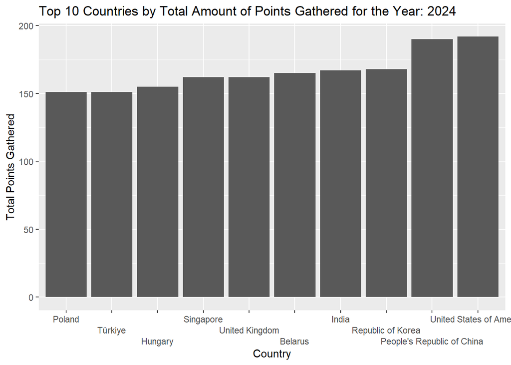

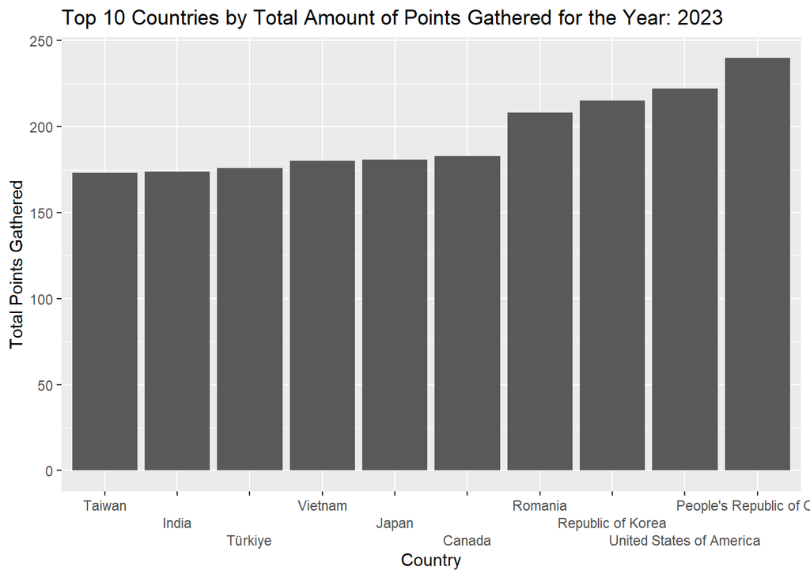

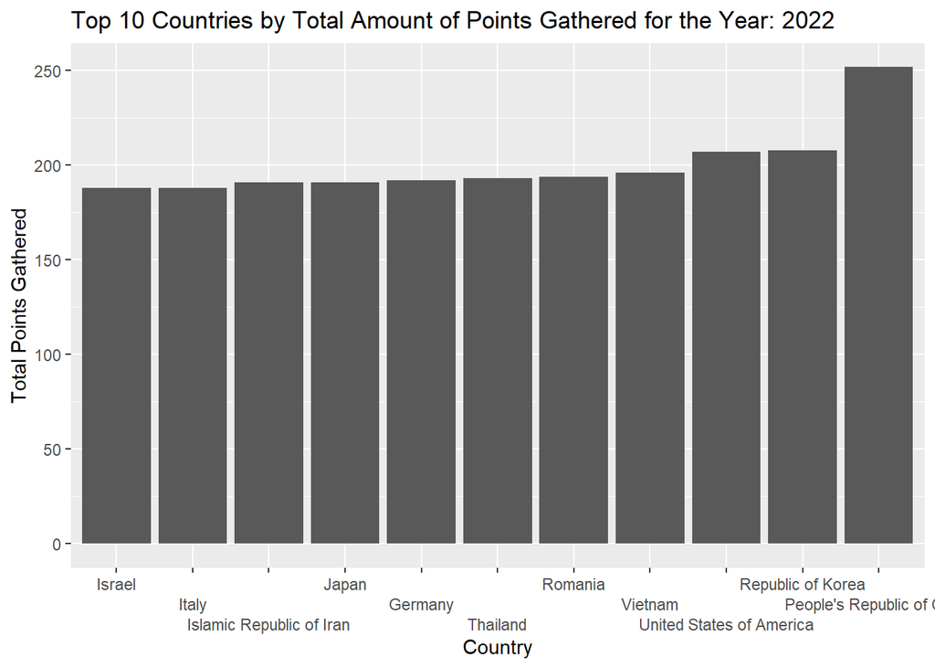

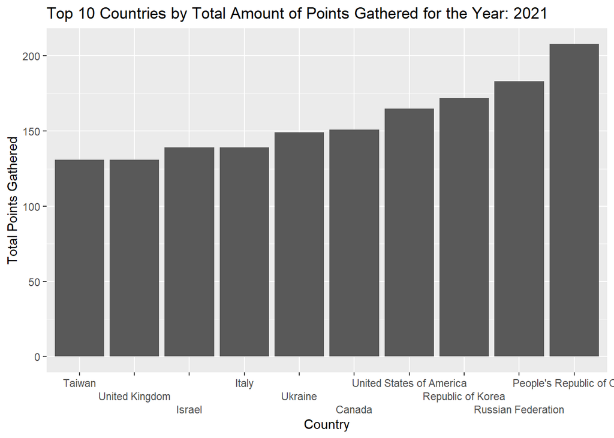

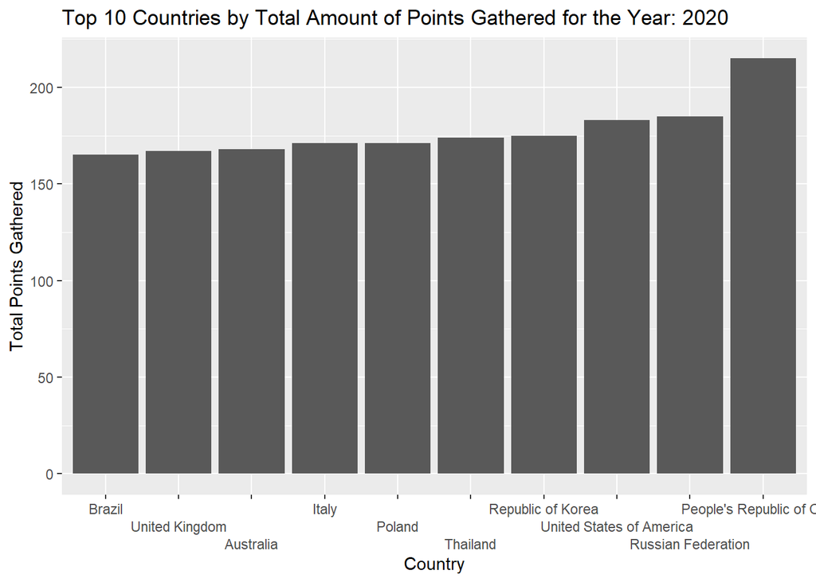

## What is the distribution of participation by gender?

### Per Year

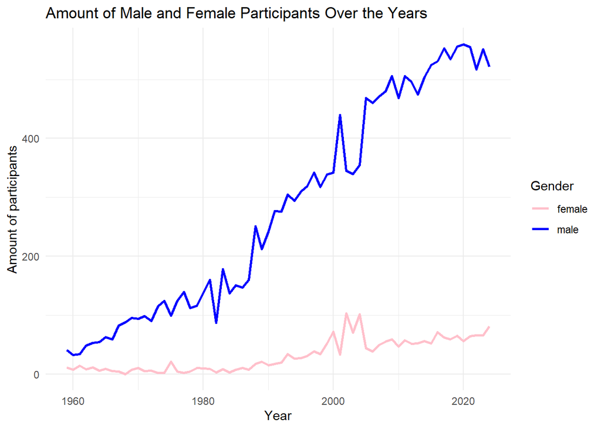

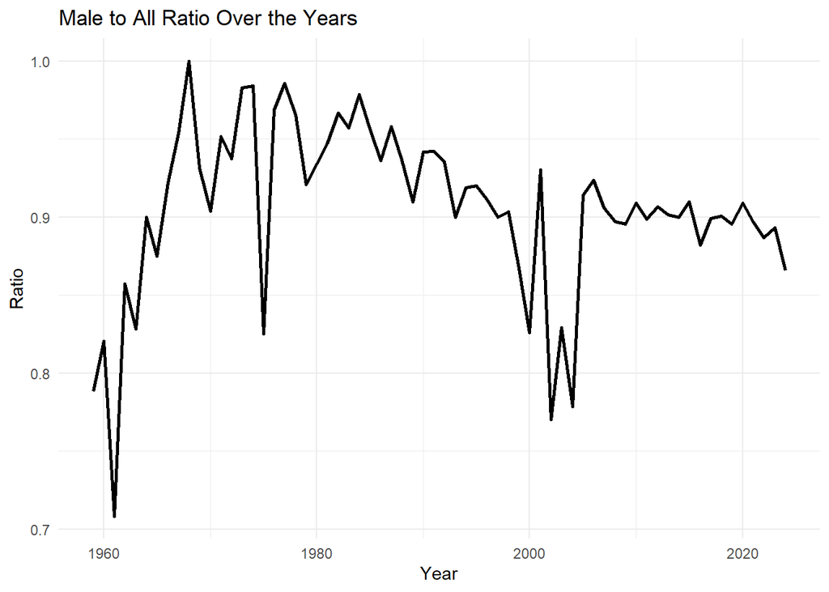

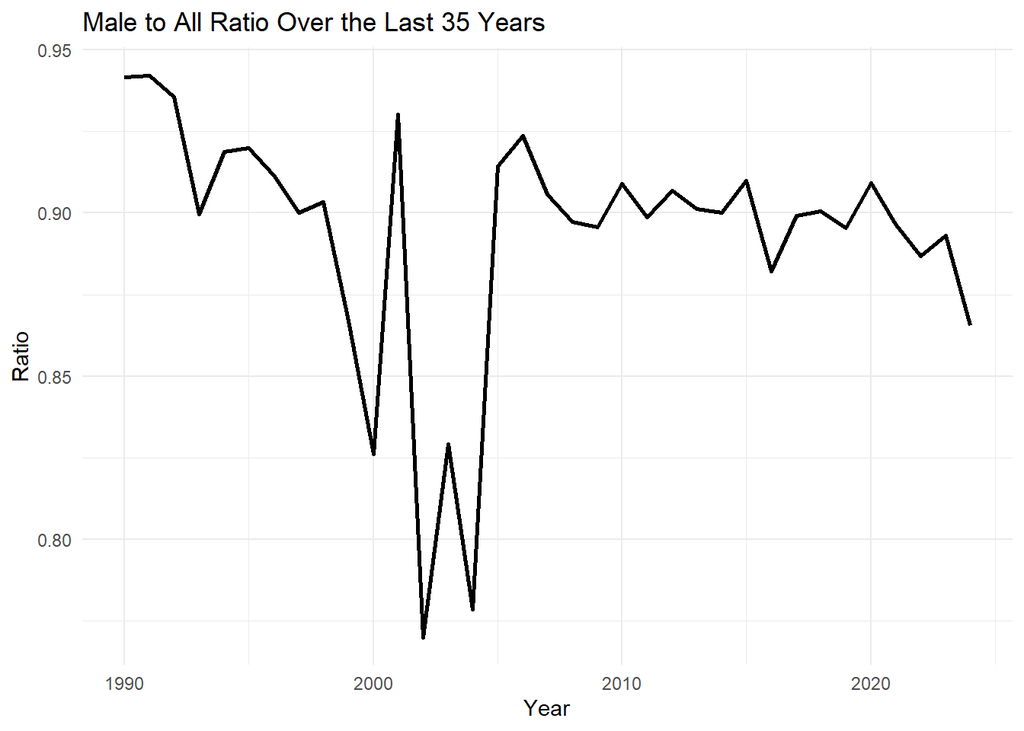

### Per Country

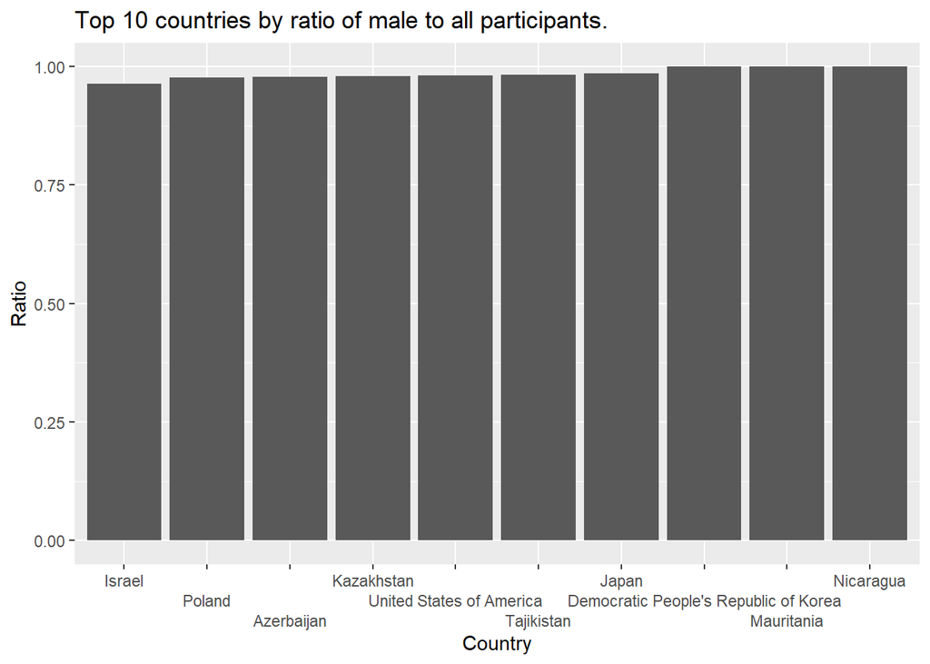

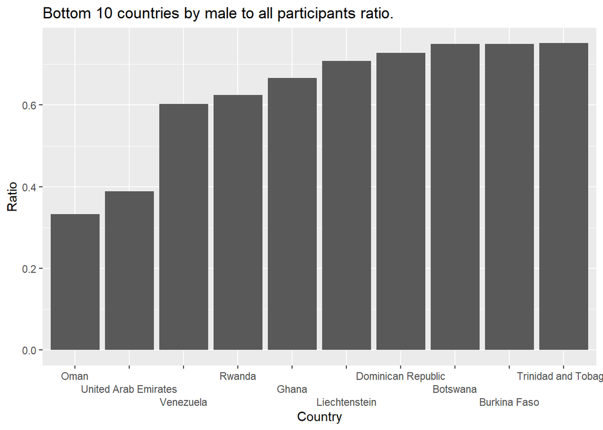

As we can see in the data the male to all ratio in most countries fits between 75 to 90 percent. At the bottom are the countries Oman, UAE, Venezuela and at the top Democratic People’s Republic of Korea, Mauritania and Nicaragua. In the data analysis above were excluded people whose gender is unknown from the data and countries that have barely participated in the contest (having less than 12 participants with known gender).